# Youth Drug Use

Tyler Franck

2025-04-14

```r
library(tidyverse)
library(ROCR)
library(caret)
library(tree)
library(randomForest)
library(gbm)
```

```r
# plot ROC curve for given predicted and truth values
rocplot <- function(pred, truth, ...) {
  pred_obj <- prediction(pred, truth)
  perf_obj <- performance(pred_obj, "tpr", "fpr")
  plot(perf_obj, ...)
}
```

# 1. The Data

We will explore youth drug use using a [filtered verson](https://github.com/mendible/5322/tree/main/Homework%201) of the [2023 National Survey on Drug Use and Health](https://www.samhsa.gov/data/dataset/national-survey-drug-use-and-health-2023-nsduh-2023-ds0001). Detailed documentation can be found in the codebook on the NSDUH site, but the comments in the `YouthParse.R` file are more accessible though incomplete. In summary, the data includes:

- For alcohol, marijuana, and cigarettes:
  - frequency of use over the last year/month
  - age of first use
  - have/have not used ever
  - imputed categories for drug frequency (e.g. 1-2 days, 3-5 days, 6-10 days)
- Basic demographics like sex, race, household income
- Youth-specific demographics like parental presence in the household and school attendance

```r
load("data/youth_data.Rdata")
df[1:3,]
```

```
##   IRALCFY IRMJFY IRCIGFM IRSMKLSS30N IRALCFM IRMJFM IRCIGAGE IRSMKLSSTRY
## 1     991    991      91          91      91     91      991         991
## 2     991     60      91          91      91      2      991         991
## 3       1    991      91          91      93     91      991         991
##   IRALCAGE IRMJAGE MRJFLAG ALCFLAG TOBFLAG ALCYDAYS MRJYDAYS ALCMDAYS MRJMDAYS
## 1      991     991       0       0       0        6        6        5        5
## 2      991      14       1       0       0        6        3        5        1
## 3       11     991       0       1       0        1        6        5        5
##   CIGMDAYS SMKLSMDAYS SCHFELT TCHGJOB AVGGRADE STNDSCIG STNDSMJ STNDALC STNDDNK
## 1        6          5       1       1        2        2       2       2       2
## 2        6          5       2       1        2        1       1       1       1
## 3        6          5       1       1        2        2       2       2       2
##   PARCHKHW PARHLPHW PRCHORE2 PRLMTTV2 PARLMTSN PRGDJOB2 PRPROUD2 ARGUPAR
## 1        1        1        1        2        1        1        1       1
## 2        1        1        2        2        1        1        1       1
```

[output cut: 25 more lines]

```r
# columns related to substance use
substance_cols
```

```
##  [1] "IRALCFY"     "IRMJFY"      "IRCIGFM"     "IRSMKLSS30N" "IRALCFM"
##  [6] "IRMJFM"      "IRCIGAGE"    "IRSMKLSSTRY" "IRALCAGE"    "IRMJAGE"
## [11] "MRJFLAG"     "ALCFLAG"     "TOBFLAG"     "ALCYDAYS"    "MRJYDAYS"
## [16] "ALCMDAYS"    "MRJMDAYS"    "CIGMDAYS"    "SMKLSMDAYS"
```

```r
# columns related to youth demographics
demographic_cols
```

```
##  [1] "IRSEX"      "NEWRACE2"   "HEALTH2"    "EDUSCHLGO"  "EDUSCHGRD2"
##  [6] "EDUSKPCOM"  "IMOTHER"    "IFATHER"    "INCOME"     "GOVTPROG"
## [11] "POVERTY3"   "PDEN10"     "COUTYP4"
```

```r
# columns related to youth experience
youth_experience_cols
```

```
##  [1] "SCHFELT"  "TCHGJOB"  "AVGGRADE" "STNDSCIG" "STNDSMJ"  "STNDALC"
##  [7] "STNDDNK"  "PARCHKHW" "PARHLPHW" "PRCHORE2" "PRLMTTV2" "PARLMTSN"
## [13] "PRGDJOB2" "PRPROUD2" "ARGUPAR"  "YOFIGHT2" "YOGRPFT2" "YOHGUN2"
## [19] "YOSELL2"  "YOSTOLE2" "YOATTAK2" "PRPKCIG2" "PRMJEVR2" "PRMJMO"
## [25] "PRALDLY2" "YFLPKCG2" "YFLTMRJ2" "YFLMJMO"  "YFLADLY2" "FRDPCIG2"
## [31] "FRDMEVR2" "FRDMJMON" "FRDADLY2" "TALKPROB" "PRTALK3"  "PRBSOLV2"
## [37] "PREVIOL2" "PRVDRGO2" "GRPCNSL2" "PREGPGM2" "YTHACT2"  "DRPRVME3"
## [43] "ANYEDUC3" "RLGATTD"  "RLGIMPT"  "RLGDCSN"  "RLGFRND"
```

# 2. The Question

We are tasked with investigating the factors that correlate with youth drug usage. In particular, we will try to answer the following question: *Which demographic, behavioral, and social factors best predict ongoing* drug usage, and do these predictors differ for alcohol, marijuana, and cigarettes? As per the assignment specification, we must include an example of binary classification, multi-class classification, and regression, and so we will apply each to one of alcohol, marijuana, and cigarette usage.

```r
# non-substance related columns (this is just convenient because we always use these as predictors)
df_non_substance <- cbind(df[,demographic_cols],df[,youth_experience_cols])
```

# 3. Modeling

## 3.1 Alcohol (Binary)

We want to find the predictors that best track ongoing alcohol usage, for which we will use a binary variable that indicates whether or not they’ve used alcohol in the past 30 days. We need to be careful to exclude “equivalent” variables from our analysis (e.g., we shouldn’t try to predict binary usage with the *number of times* they’ve use it).

```r
alcohol <- df_non_substance

# IRALCFM = 91 (never used alcohol), 93 (didn't use in past month)
alcohol[,"ALCOHOL"] <- factor(ifelse(df[,"IRALCFM"]<91,1,0))

alcohol[1:3,]
```

```
##   IRSEX NEWRACE2 HEALTH2 EDUSCHLGO EDUSCHGRD2 EDUSKPCOM IMOTHER IFATHER INCOME
## 1     1        7       3         1          3         0       1       1      2
## 2     2        1       4         1          6         0       1       1      2
## 3     1        6       1         1          2         1       1       1      4
##   GOVTPROG POVERTY3 PDEN10 COUTYP4 SCHFELT TCHGJOB AVGGRADE STNDSCIG STNDSMJ
## 1        2        1      2       2       1       1        2        2       2
## 2        2        1      2       2       2       1        2        1       1
## 3        2        3      1       1       1       1        2        2       2
##   STNDALC STNDDNK PARCHKHW PARHLPHW PRCHORE2 PRLMTTV2 PARLMTSN PRGDJOB2
## 1       2       2        1        1        1        2        1        1
## 2       1       1        1        1        2        2        1        1
## 3       2       2        1        1        1        1        1        2
##   PRPROUD2 ARGUPAR YOFIGHT2 YOGRPFT2 YOHGUN2 YOSELL2 YOSTOLE2 YOATTAK2 PRPKCIG2
## 1        1       1        2        2       2       2        2        2        1
## 2        1       1        2        2       2       2        2        2        1
## 3        1       1        1        1       2       2        2        2        1
##   PRMJEVR2 PRMJMO PRALDLY2 YFLPKCG2 YFLTMRJ2 YFLMJMO YFLADLY2 FRDPCIG2 FRDMEVR2
## 1        1      1        1        1        1       1        1        1        1
## 2        2      2        1        1        1       2        1        2        2
## 3        1      1        1        1        1       1        1        1        1
##   FRDMJMON FRDADLY2 TALKPROB PRTALK3 PRBSOLV2 PREVIOL2 PRVDRGO2 GRPCNSL2
## 1        1        1        2       1        1        1        2        2
## 2        2        2        2       1        2        2        2        2
## 3        1        1        2       1        2        2        2        2
##   PREGPGM2 YTHACT2 DRPRVME3 ANYEDUC3 RLGATTD RLGIMPT RLGDCSN RLGFRND ALCOHOL
## 1        2       2        1        1       2       1       1       1       0
## 2        2       1        2        1       2       2       2       2       0
## 3        2       2        1        1       2       1       1       2       0
```

```r
set.seed(5322)

# 75/25 train/test split
train <- sample(1:nrow(alcohol), 0.75*nrow(alcohol))
test <- -(train)
alcohol.train <- alcohol[train,]
alcohol.test <- alcohol[test,]
```

### 3.1.1 Decision Tree

```r
tree.alcohol <- tree(ALCOHOL ~ ., alcohol.train)
summary(tree.alcohol)
```

```
##
## Classification tree:
## tree(formula = ALCOHOL ~ ., data = alcohol.train)
## Variables actually used in tree construction:
## [1] "YFLMJMO"    "STNDALC"    "EDUSCHGRD2"
## Number of terminal nodes:  5
## Residual mean deviance:  0.4456 = 2766 / 6208
## Misclassification error rate: 0.07613 = 473 / 6213
```

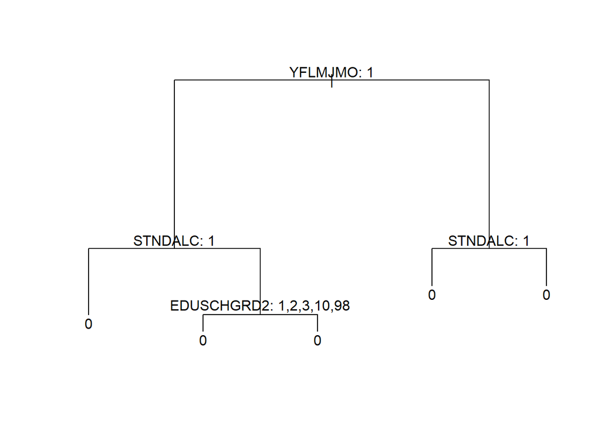

```r
plot(tree.alcohol)
text(tree.alcohol,pretty=0)
```

That the decision tree just predicts the most common response might be evidence that none of the predictors are particularly useful, though we will hold off on making this conclusion. At least this gives us chance to get the base-line metrics of a model that just guesses the most common response:

```r
y_pred <- predict(tree.alcohol,alcohol.test,type="class")
truth <- alcohol.test$ALCOHOL

print(caret::confusionMatrix(table(y_pred,truth)))
```

```
## Confusion Matrix and Statistics
##
##       truth
## y_pred    0    1
##      0 2455  186
##      1    0    0
##
##                Accuracy : 0.9296
##                  95% CI : (0.9191, 0.939)
##     No Information Rate : 0.9296
##     P-Value [Acc > NIR] : 0.5195
##
##                   Kappa : 0
##
##  Mcnemar's Test P-Value : <2e-16
##
##             Sensitivity : 1.0000
##             Specificity : 0.0000
##          Pos Pred Value : 0.9296
##          Neg Pred Value :    NaN
##              Prevalence : 0.9296
##          Detection Rate : 0.9296
##    Detection Prevalence : 1.0000
##       Balanced Accuracy : 0.5000
##
##        'Positive' Class : 0
##
```

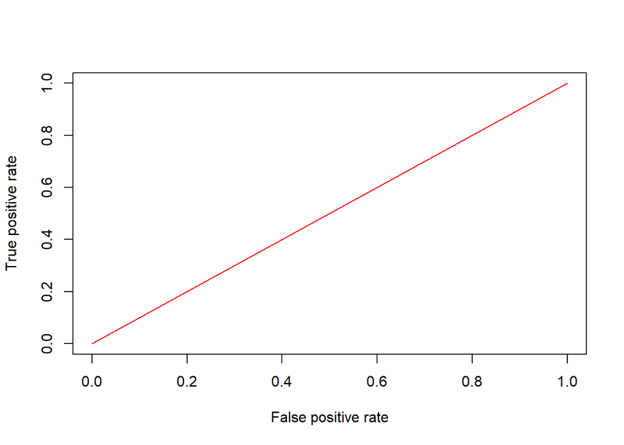

```r
rocplot(as.numeric(y_pred),truth, col="red")  # base-line "y=x" as you'd expect
```

The `randomForest` function doesn’t work with missing values, and so we must either impute these values or drop them. For simplicity, we will just drop them, though this could bias our results.

```r
# effect across train and test sets should be consistent due to random sampling
alcohol.train.nna <- na.omit(alcohol.train)  # 7920 -> 6213 rows
alcohol.test.nna <- na.omit(alcohol.test)    # 2641 -> 2036 rows
```

```r
# number of predictors
p <- ncol(alcohol)-1
p
```

```
## [1] 60
```

```r
set.seed(5322)

bag.alcohol <- randomForest(
  ALCOHOL ~ .,
  alcohol.train.nna,
  mtry=p,
  importance=TRUE
)
bag.alcohol
```

```
##
## Call:
##  randomForest(formula = ALCOHOL ~ ., data = alcohol.train.nna,      mtry = p, importance = TRUE)
##                Type of random forest: classification
##                      Number of trees: 500
## No. of variables tried at each split: 60
##
##         OOB estimate of  error rate: 7.63%
## Confusion matrix:
##      0  1 class.error
## 0 5677 63  0.01097561
## 1  411 62  0.86892178
```

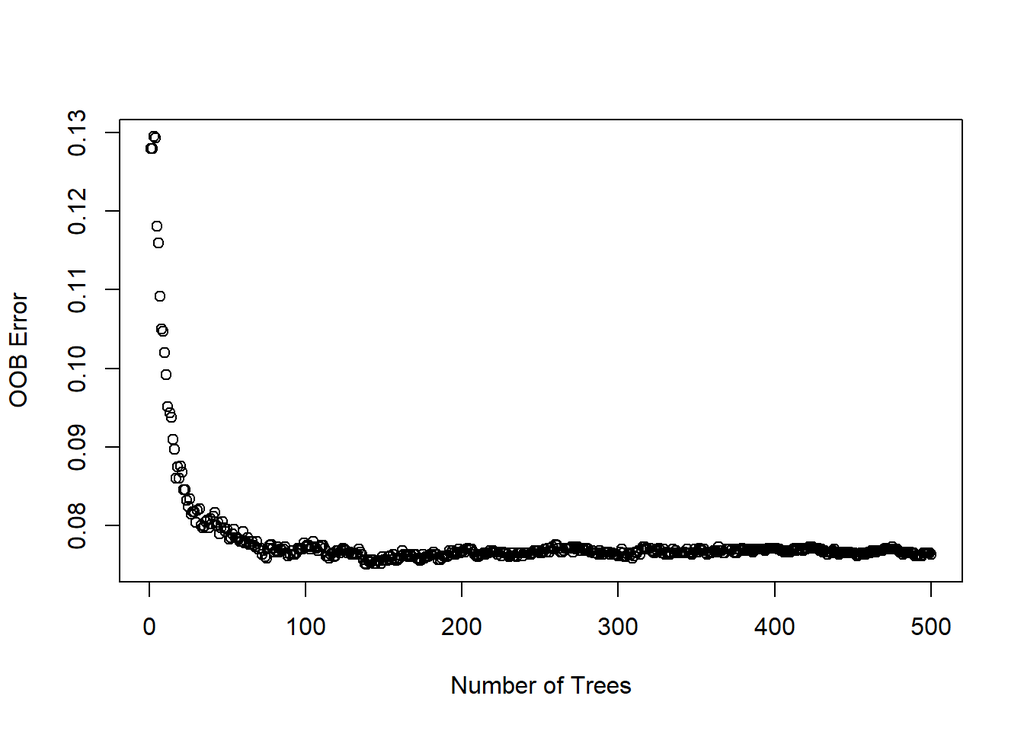

```r
# for future reference, ~100 trees is probably enough
plot(
  x=1:bag.alcohol$ntree,
  xlab="Number of Trees",
  y=bag.alcohol$err.rate[,"OOB"],
  ylab="OOB Error"
)
```

```r
# Is our model actually useful?
y_pred <- predict(bag.alcohol,alcohol.test.nna,type="class")
truth <- alcohol.test.nna$ALCOHOL

print(caret::confusionMatrix(table(y_pred,truth)))
```

```
## Confusion Matrix and Statistics
##
##       truth
## y_pred    0    1
##      0 1860  143
##      1   12   21
##
##                Accuracy : 0.9239
##                  95% CI : (0.9115, 0.935)
##     No Information Rate : 0.9194
##     P-Value [Acc > NIR] : 0.2463
##
##                   Kappa : 0.1914
##
##  Mcnemar's Test P-Value : <2e-16
##
##             Sensitivity : 0.9936
##             Specificity : 0.1280
##          Pos Pred Value : 0.9286
##          Neg Pred Value : 0.6364
##              Prevalence : 0.9194
##          Detection Rate : 0.9136
##    Detection Prevalence : 0.9838
##       Balanced Accuracy : 0.5608
##
##        'Positive' Class : 0
##
```

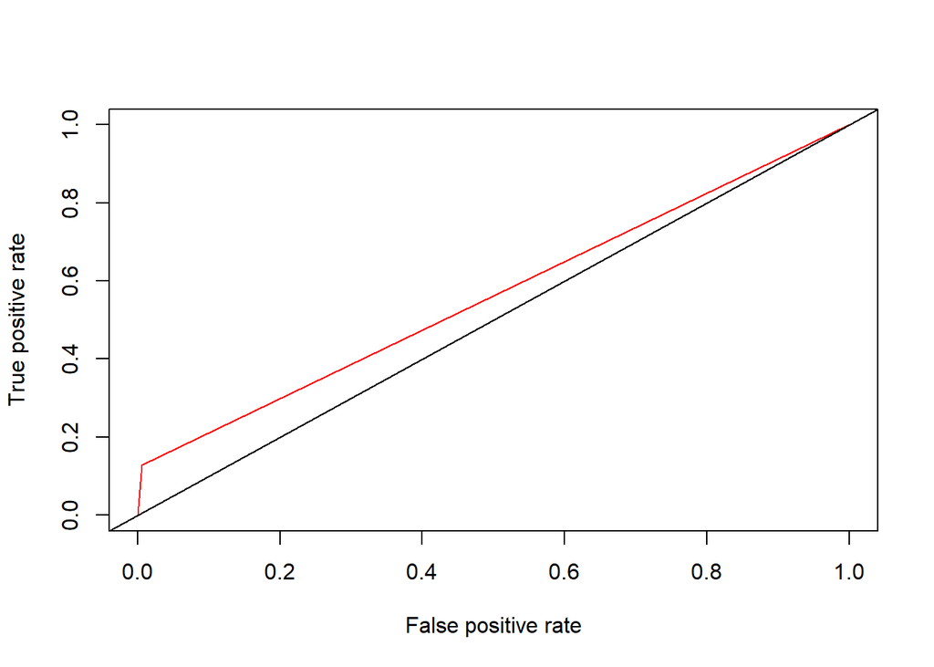

```r
rocplot(as.numeric(y_pred),truth, col="red")  # base-line "y=x" as you'd expect
abline(0,1)
```

Our model is performing *slightly* better than just guessing the most common response! Let’s see which predictors it thinks are most important:

```r
# Variable importance plots
importance(bag.alcohol)
```

```
##                     0             1 MeanDecreaseAccuracy MeanDecreaseGini
## IRSEX      -0.2419106  1.6738779569           0.45062475        11.472590
## NEWRACE2    9.1859270  2.3390674688           9.53190711        47.183260
## HEALTH2     2.6942039 -1.3605680584           1.94902270        48.948979
## EDUSCHLGO   0.5272748 -2.1370444675          -0.09388756         6.004506
## EDUSCHGRD2  5.3610652 17.3220183522          11.92294568        62.329842
## EDUSKPCOM   9.2368169 -6.3377313509           6.91261580        42.078761
## IMOTHER    -5.7968282  3.6172670892          -3.83217718        11.428410
## IFATHER     3.0682263  6.6687543988           5.97556261        13.171493
## INCOME     18.4990420 15.8907632338          25.46516457        39.487301
## GOVTPROG   10.7357977  2.2512636442          11.43674325         7.738280
## POVERTY3   15.7193577 -2.1708149508          15.60329610        18.882425
## PDEN10      8.2112468 -1.5887812659           7.92054516        15.117668
## COUTYP4     7.9523453  2.7977087938           8.80551661        21.637142
## SCHFELT     6.8078280  1.6310704634           6.94545980        12.875791
## TCHGJOB     3.5180023 -4.3269610875           1.53670777        10.500818
## AVGGRADE    2.6727251 -3.5327987111           1.20259524         5.019050
## STNDSCIG    6.0312939 -0.4369554044           5.81476305         7.925794
## STNDSMJ     8.8219896  1.9056383151           9.50393933        12.690859
## STNDALC    13.1525026 24.3343011008          23.50616192        39.742165
## STNDDNK    17.3679052 -0.0007011842          17.59200315        12.234165
## PARCHKHW    0.6441643 -0.7953793789           0.26185319        10.441753
## PARHLPHW    0.3305496  7.8305009255           3.25563111        13.399671
## PRCHORE2   -0.7597887  2.3495833739           0.23655047        11.256802
## PRLMTTV2    0.6516934 -4.3945461141          -1.14897661         8.731946
## PARLMTSN    4.2171444 -2.9636668127           2.79538140        12.285954
## PRGDJOB2   11.6370336  1.1490816166          11.89306526         8.741972
## PRPROUD2    1.8801414  2.4583568420           2.84355717         8.330065
## ARGUPAR    -4.5680889  3.8917527810          -2.53884763        13.233433
## YOFIGHT2   10.2449005  0.1636808943          10.23590988         8.464262
## YOGRPFT2    0.9178050  0.9797012242           1.22470203         8.310363
## YOHGUN2     2.1380749  5.7332906448           4.11309292        10.993542
## YOSELL2    15.7701947 12.5608296040          18.98745375        11.630770
## YOSTOLE2   14.0930071 13.7944406681          18.96950975        17.165640
## YOATTAK2   -0.5485153  3.1246514137           0.88363827         6.857746
## PRPKCIG2    5.9054304 -0.8706346884           5.17632046         6.014506
## PRMJEVR2    7.5892859  5.6760695166          10.43780906         9.670842
## PRMJMO      2.1402934  9.5815949860           7.30686778        13.558284
## PRALDLY2   13.4044092 10.8599281556          16.09305634        15.064020
## YFLPKCG2   24.6987473 -6.7078981791          24.00988670         7.960907
## YFLTMRJ2   27.8862527 -9.7335588401          26.56310283        11.137320
## YFLMJMO    31.3701738  8.8727207706          33.67495580        44.141435
## YFLADLY2    7.6061516  3.8199781662           8.86373664         9.366960
## FRDPCIG2   11.9342019 -3.4249597297          11.12916849         6.630046
## FRDMEVR2   11.6292635  0.6776303856          12.51782538         8.242870
## FRDMJMON   15.2187333  8.9014706804          17.46925655        18.798185
## FRDADLY2   16.4940404  0.5766260942          16.48232573         9.983726
## TALKPROB   -3.4322664  2.4394400388          -2.34648286         6.856008
## PRTALK3     7.6397499  1.1195044403           7.33589244        15.407199
## PRBSOLV2    3.3380453 -0.3544896636           2.96222792        10.072195
## PREVIOL2    5.2352240 -3.8606325519           3.76784347         4.874130
## PRVDRGO2   -0.2655628 -0.6053390501          -0.50444189         5.775559
## GRPCNSL2    5.6686852 -1.3700651549           5.18413994         3.115238
## PREGPGM2    5.8430951 -1.4050494785           5.14255600         4.629159
## YTHACT2     2.1359764 -2.0420875558           1.10790324         7.899323
## DRPRVME3    0.3000990  5.8671820287           3.21277671        10.004396
## ANYEDUC3    2.9911288  1.0726692096           3.15781935        10.354122
## RLGATTD     4.5204530 -4.0448109315           2.72764995         8.524434
## RLGIMPT     8.6259485 -3.3912901389           7.21922080        10.684052
## RLGDCSN     8.4681370 -4.8001983129           6.49913614         9.672718
## RLGFRND     8.2444361 -5.9911610180           5.92428137         9.974327
```

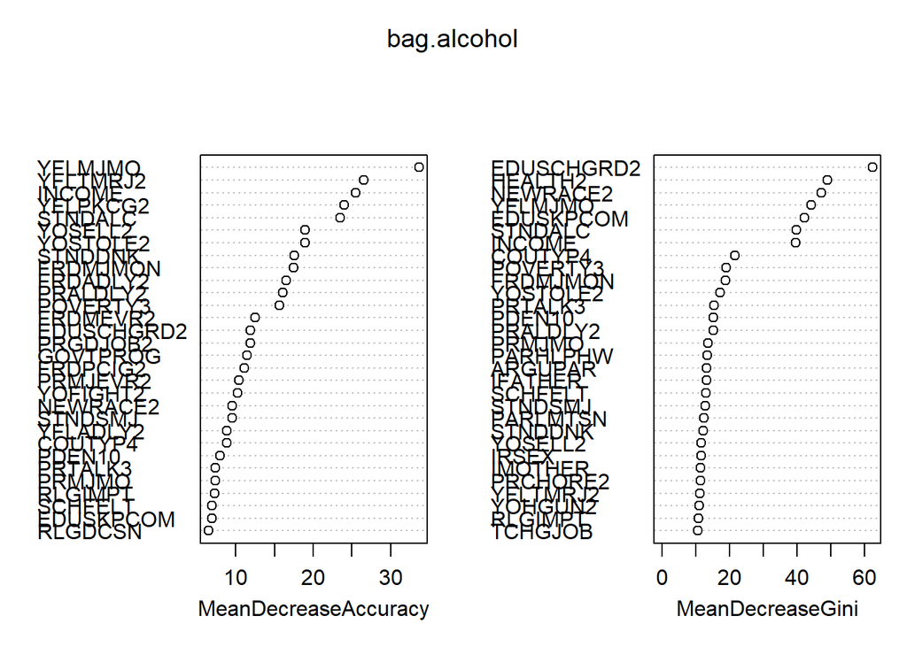

```r
varImpPlot(bag.alcohol)
```

## 3.2 Marijuana (Multi-class)

```r
marijuana <- df_non_substance

# # days used in past month (0=none, 1=1-2, 2=3-5, 3=6-19, 4=20-30)
marijuana$MARIJUANA <- df$MRJMDAYS
marijuana[marijuana$MARIJUANA==5,"MARIJUANA"] <- 0  # change 5=none to 0=none
marijuana$MARIJUANA <- factor(marijuana$MARIJUANA)
marijuana[1:3,]
```

```
##   IRSEX NEWRACE2 HEALTH2 EDUSCHLGO EDUSCHGRD2 EDUSKPCOM IMOTHER IFATHER INCOME
## 1     1        7       3         1          3         0       1       1      2
## 2     2        1       4         1          6         0       1       1      2
## 3     1        6       1         1          2         1       1       1      4
##   GOVTPROG POVERTY3 PDEN10 COUTYP4 SCHFELT TCHGJOB AVGGRADE STNDSCIG STNDSMJ
## 1        2        1      2       2       1       1        2        2       2
## 2        2        1      2       2       2       1        2        1       1
## 3        2        3      1       1       1       1        2        2       2
##   STNDALC STNDDNK PARCHKHW PARHLPHW PRCHORE2 PRLMTTV2 PARLMTSN PRGDJOB2
## 1       2       2        1        1        1        2        1        1
## 2       1       1        1        1        2        2        1        1
## 3       2       2        1        1        1        1        1        2
##   PRPROUD2 ARGUPAR YOFIGHT2 YOGRPFT2 YOHGUN2 YOSELL2 YOSTOLE2 YOATTAK2 PRPKCIG2
## 1        1       1        2        2       2       2        2        2        1
## 2        1       1        2        2       2       2        2        2        1
## 3        1       1        1        1       2       2        2        2        1
##   PRMJEVR2 PRMJMO PRALDLY2 YFLPKCG2 YFLTMRJ2 YFLMJMO YFLADLY2 FRDPCIG2 FRDMEVR2
## 1        1      1        1        1        1       1        1        1        1
## 2        2      2        1        1        1       2        1        2        2
## 3        1      1        1        1        1       1        1        1        1
##   FRDMJMON FRDADLY2 TALKPROB PRTALK3 PRBSOLV2 PREVIOL2 PRVDRGO2 GRPCNSL2
## 1        1        1        2       1        1        1        2        2
## 2        2        2        2       1        2        2        2        2
## 3        1        1        2       1        2        2        2        2
##   PREGPGM2 YTHACT2 DRPRVME3 ANYEDUC3 RLGATTD RLGIMPT RLGDCSN RLGFRND MARIJUANA
## 1        2       2        1        1       2       1       1       1         0
## 2        2       1        2        1       2       2       2       2         1
## 3        2       2        1        1       2       1       1       2         0
```

```r
set.seed(5322)

# 75/25 train/test split
train <- sample(1:nrow(marijuana), 0.75*nrow(marijuana))
test <- -(train)
marijuana.train <- marijuana[train,]
marijuana.test <- marijuana[test,]
```

### 3.2.1 Decision Tree

```r
tree.marijuana <- tree(MARIJUANA ~ ., marijuana.train)
summary(tree.marijuana)
```

```
##
## Classification tree:
## tree(formula = MARIJUANA ~ ., data = marijuana.train)
## Variables actually used in tree construction:
## [1] "FRDMJMON" "PRMJMO"   "STNDSMJ"  "YOSELL2"  "PRMJEVR2"
## Number of terminal nodes:  7
## Residual mean deviance:  0.5633 = 3496 / 6206
## Misclassification error rate: 0.07356 = 457 / 6213
```

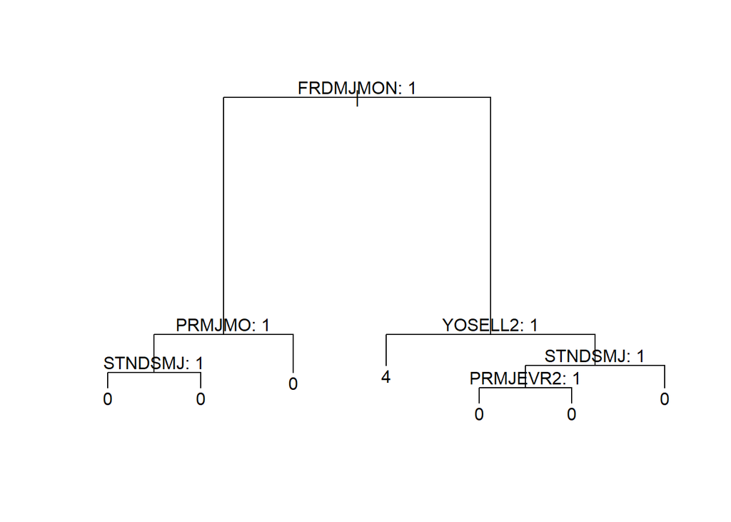

```r
plot(tree.marijuana)
text(tree.marijuana,pretty=0)
```

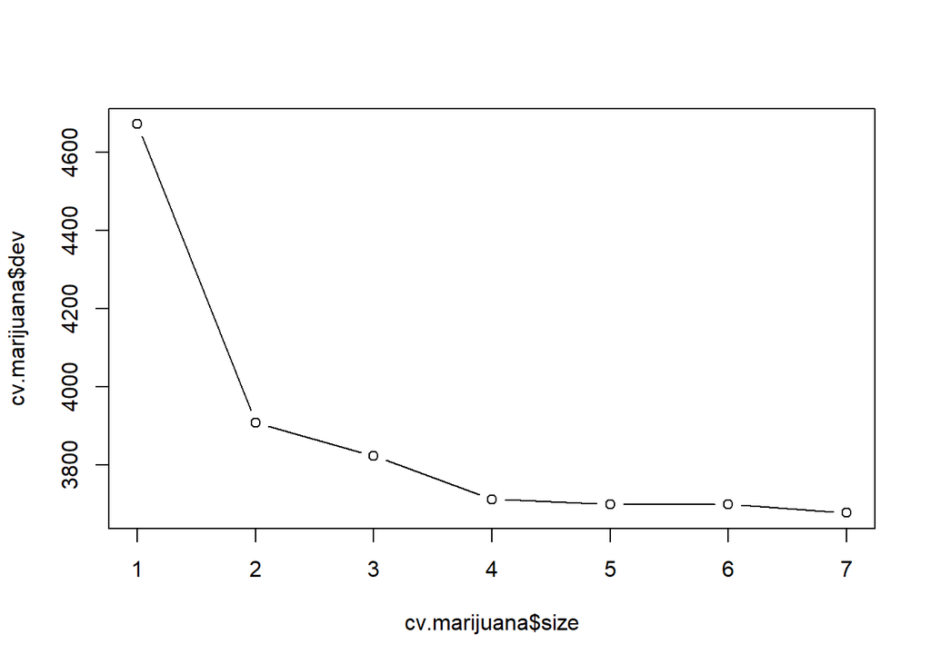

```r
# tree is pretty complex, let's try pruning
cv.marijuana <- cv.tree(tree.marijuana)
plot(cv.marijuana$size, cv.marijuana$dev, type = "b")
```

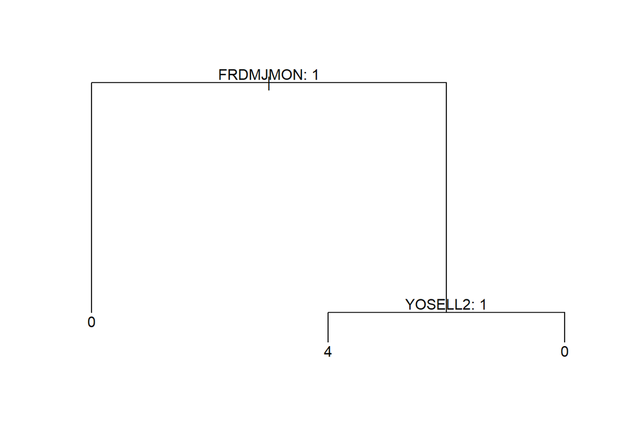

```r
# size = 3 looks like a good choice
prune.marijuana <- prune.misclass(tree.marijuana, best = 3)
plot(prune.marijuana)
text(prune.marijuana, pretty = 0)
```

```r
y_pred <- predict(prune.marijuana,marijuana.test,type="class")
truth <- marijuana.test$MARIJUANA

print(caret::confusionMatrix(table(y_pred,truth)))
```

```
## Confusion Matrix and Statistics
##
##       truth
## y_pred    0    1    2    3    4
##      0 2442   48   44   49   40
##      1    0    0    0    0    0
##      2    0    0    0    0    0
##      3    0    0    0    0    0
##      4    3    1    4    4    6
##
## Overall Statistics
##
##                Accuracy : 0.9269
##                  95% CI : (0.9163, 0.9366)
##     No Information Rate : 0.9258
##     P-Value [Acc > NIR] : 0.4304
##
##                   Kappa : 0.0911
##
##  Mcnemar's Test P-Value : NA
##
## Statistics by Class:
##
##                      Class: 0 Class: 1 Class: 2 Class: 3 Class: 4
## Sensitivity           0.99877  0.00000  0.00000  0.00000 0.130435
## Specificity           0.07653  1.00000  1.00000  1.00000 0.995376
## Pos Pred Value        0.93100      NaN      NaN      NaN 0.333333
## Neg Pred Value        0.83333  0.98145  0.98183  0.97993 0.984750
## Prevalence            0.92579  0.01855  0.01817  0.02007 0.017418
## Detection Rate        0.92465  0.00000  0.00000  0.00000 0.002272
## Detection Prevalence  0.99318  0.00000  0.00000  0.00000 0.006816
## Balanced Accuracy     0.53765  0.50000  0.50000  0.50000 0.562905
```

Our model seems to be capturing something about the least and most frequent users, but nothing about the middle frequencies (it never predicts 1-3). But being able to identify heavy usage is still useful. It gets this predictive power from the following predictors:

- `FRDMJMON`: how close friends feel about marijuana
- `YOSELL2`: whether youth sells illegal drugs

### 3.2.2 Random Forest

```r
# effect across train and test sets should be consistent due to random sampling
marijuana.train.nna <- na.omit(marijuana.train)  # 7920 > 6213 rows
marijuana.test.nna <- na.omit(marijuana.test)    # 2641 > 2036 rows
```

```r
# number of predictors
p <- ncol(marijuana)-1
p
```

```
## [1] 60
```

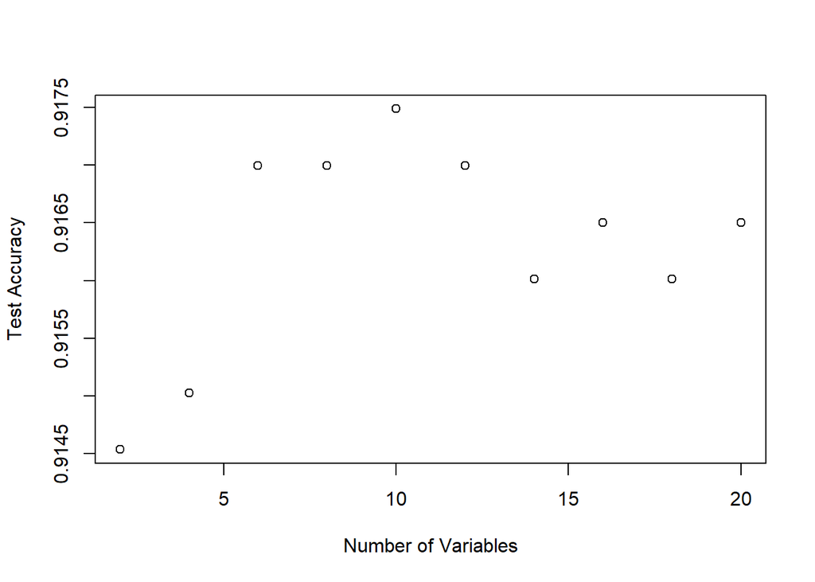

```r
set.seed(5322)

ms <- 2*(1:(p/6))  # try up to p/3 predictors (skipping by 2 for quicker compute)
accuracy <- rep(0,length(ms))  # validation accuracy
for (i in 1:length(ms)) {
  # train model and get validation accuracy of current m
  rf.marijuana.nna <- randomForest(MARIJUANA ~ ., marijuana.train.nna, mtry=ms[i])
  accuracy[i] <- mean(predict(rf.marijuana.nna,marijuana.test.nna,type="class")==marijuana.test.nna$MARIJUANA)
}
plot(
  x=ms,
  xlab="Number of Variables",
  y=accuracy,
  ylab="Test Accuracy"
)
```

```r
set.seed(5322)

# m = 10 seems like a good choice
m <- 10
rf.marijuana <- randomForest(MARIJUANA ~ ., marijuana.train.nna, mtry=m, importance=TRUE)
rf.marijuana
```

```
##
## Call:
##  randomForest(formula = MARIJUANA ~ ., data = marijuana.train.nna,      mtry = m, importance = TRUE)
##                Type of random forest: classification
##                      Number of trees: 500
## No. of variables tried at each split: 10
##
##         OOB estimate of  error rate: 7.36%
## Confusion matrix:
##      0 1 2 3  4 class.error
## 0 5730 0 0 0  7  0.00122015
## 1  124 0 0 0  1  1.00000000
## 2   84 0 0 0  2  1.00000000
## 3  119 0 0 1  3  0.99186992
## 4  117 0 0 0 25  0.82394366
```

```r
# How does it perform?
y_pred <- predict(rf.marijuana,marijuana.test.nna,type="class")
truth <- marijuana.test.nna$MARIJUANA

print(caret::confusionMatrix(table(y_pred,truth)))
```

```
## Confusion Matrix and Statistics
##
##       truth
## y_pred    0    1    2    3    4
##      0 1862   41   41   42   40
##      1    0    0    0    0    0
##      2    0    0    0    0    0
##      3    0    0    0    0    0
##      4    0    1    0    3    6
##
## Overall Statistics
##
##                Accuracy : 0.9175
##                  95% CI : (0.9047, 0.9291)
##     No Information Rate : 0.9145
##     P-Value [Acc > NIR] : 0.3347
##
##                   Kappa : 0.0816
##
##  Mcnemar's Test P-Value : NA
##
## Statistics by Class:
##
##                      Class: 0 Class: 1 Class: 2 Class: 3 Class: 4
## Sensitivity           1.00000  0.00000  0.00000   0.0000 0.130435
## Specificity           0.05747  1.00000  1.00000   1.0000 0.997990
## Pos Pred Value        0.91905      NaN      NaN      NaN 0.600000
## Neg Pred Value        1.00000  0.97937  0.97986   0.9779 0.980257
## Prevalence            0.91454  0.02063  0.02014   0.0221 0.022593
## Detection Rate        0.91454  0.00000  0.00000   0.0000 0.002947
## Detection Prevalence  0.99509  0.00000  0.00000   0.0000 0.004912
## Balanced Accuracy     0.52874  0.50000  0.50000   0.5000 0.564212
```

Like the decision tree, the random forest achieves non-trivial balanced accuracy for the lowest and highest frequencies, so looking at the variable importance is meaningful.

```r
# variable importance plots
importance(rf.marijuana)
```

```
##                      0            1             2           3           4
## IRSEX       3.03754686 -0.423464236  0.5794493823 -1.90862941 -1.80728842
## NEWRACE2    2.16035025 -3.126633808  1.3477070831  0.03445701 -0.16256539
## HEALTH2    -3.81477372  0.347703099  2.4938000224 -0.40830680  7.23335854
## EDUSCHLGO   1.19502676  0.335303898 -0.1387656648 -1.72769544  1.08336743
## EDUSCHGRD2  3.56510050 -2.856777628 -0.0825448429  0.71808382  6.55172322
## EDUSKPCOM   2.29646580 -3.263270021  0.5407716574 -0.67019397  8.91386980
## IMOTHER    -0.26118028  0.004169169 -1.7114087597  1.07926342  0.60939550
## IFATHER     1.25473019  1.453996514 -1.9227408048 -0.53357631 -1.59593627
## INCOME      8.82358321  0.081201894 -0.2254203702 -2.00935635  0.56417923
## GOVTPROG    4.39246118 -1.049407565  1.2888277655  0.33912908  1.60015315
## POVERTY3    8.34285812 -2.535529620 -0.0893683626 -0.59758750  0.27328479
## PDEN10      3.05263418 -0.495161850 -1.8955052841 -0.16538603 -3.32090048
## COUTYP4     4.22992370 -3.217385955  0.4636970168 -0.04806009 -2.65577710
## SCHFELT     1.79771404 -2.989474311 -1.5670606736 -0.27622606  4.65446526
## TCHGJOB    -2.48697423  0.612361579 -1.9366615326 -0.24306949 -0.06488166
## AVGGRADE   -2.62650103  0.907720764  2.2674194018  1.12632432  0.24523371
## STNDSCIG    0.90687116 -0.124617940 -0.5661776351 -1.34807222 -0.00447827
## STNDSMJ    -4.69104984 -3.450210791  5.2960461224  6.72457593 14.84939039
## STNDALC     3.58771478  2.814843915  2.0958067314  2.16244266  5.45499446
## STNDDNK     5.36388181  0.564489078 -0.8115472828 -0.94596210  7.31495665
## PARCHKHW   -3.05282691 -2.294410817  0.1214591961 -0.76510357  5.20680688
## PARHLPHW   -2.09074535 -0.818042252 -0.4653274109  1.42562771  3.94185601
## PRCHORE2   -3.52711694  1.432014287 -1.4634589619 -0.71927630 -2.14550673
## PRLMTTV2    3.73333149 -0.716885427  0.1306666729  0.80438429  2.72973744
## PARLMTSN    4.13399950 -0.518659695  0.6298067913 -0.67904353 -0.03762642
## PRGDJOB2   -0.58122665  2.028792438 -1.8532809067 -2.88261068  3.89156229
## PRPROUD2   -4.30072815  5.797753007 -2.1392974762 -0.32654245  3.05246442
## ARGUPAR    -1.89160575  1.538251656 -1.6518656464 -0.59097372  2.79049706
## YOFIGHT2   -0.78558843  1.163684190  1.9151005877 -0.44267045  0.73355618
## YOGRPFT2   -1.23749830 -1.449295309  2.5304253335  0.01462951  4.73125929
## YOHGUN2    -3.37100019 -0.037638301  0.7887958663  3.85055091 -0.38484239
## YOSELL2    14.01636565 -0.778693095 -0.2573999237  3.10053642 18.96053425
## YOSTOLE2    1.80070056 -0.889031023 -2.7423663649  2.71990674  9.25237598
## YOATTAK2    1.53622658  4.389380225  0.4646451948 -1.52963771  3.61051430
## PRPKCIG2    9.48338674  1.402473289 -1.8221365113 -2.88840197 -2.62773272
## PRMJEVR2    2.51293299  2.491085683  1.7826476332  1.02854340 14.70348077
## PRMJMO      5.54632294  0.724219665  0.8009766416  5.20933526 16.63892909
## PRALDLY2   -0.77474599 -1.884066430  0.2643866611  0.49240222  3.70916057
## YFLPKCG2   17.92090839 -2.648556484 -1.7781998822 -2.58181007 -0.96328700
```

[output cut: 67 more lines]

```
## FRDADLY2             9.54162275         9.259212
## TALKPROB            -3.22283008         8.164192
## PRTALK3              3.23242233        13.867804
## PRBSOLV2             0.64832427         9.468974
## PREVIOL2             2.24823358         6.016307
## PRVDRGO2             0.30233390         5.345323
## GRPCNSL2             2.00450457         3.380902
## PREGPGM2            -2.26500053         4.706978
## YTHACT2              0.39122796        11.352195
## DRPRVME3             3.01284285        13.477788
## ANYEDUC3             0.10760861        13.556532
## RLGATTD              4.14783519         6.829967
## RLGIMPT              4.10884321        12.308559
## RLGDCSN              5.12207349        12.695062
## RLGFRND              6.80045952         8.972692
```

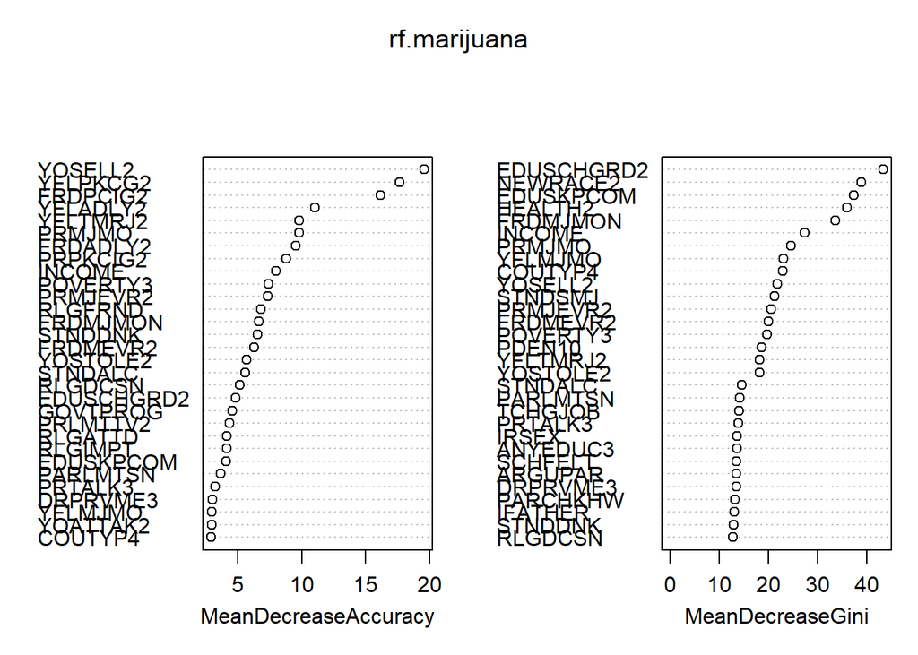

```r
varImpPlot(rf.marijuana)
```

Some promising predictors are:

- `YOSELL2`: Whether youth has sold illegal drugs
- `PRMJMO`: How (youth thinks) parents would feel about them using marijuana (monthly)
- `INCOME`: Family income
- `YFLTMRJ2`: How youth feels about peers trying marijuana

# 3.3 Cigarette (Regression)

```r
cigarette <- df_non_substance

# # days used in past month
cigarette$CIGARETTE <- df$IRCIGFM
cigarette[cigarette$CIGARETTE>90,"CIGARETTE"] <- 0  # change the "none" values (>90) to 0
cigarette[1:3,]
```

```
##   IRSEX NEWRACE2 HEALTH2 EDUSCHLGO EDUSCHGRD2 EDUSKPCOM IMOTHER IFATHER INCOME
## 1     1        7       3         1          3         0       1       1      2
## 2     2        1       4         1          6         0       1       1      2
## 3     1        6       1         1          2         1       1       1      4
##   GOVTPROG POVERTY3 PDEN10 COUTYP4 SCHFELT TCHGJOB AVGGRADE STNDSCIG STNDSMJ
## 1        2        1      2       2       1       1        2        2       2
## 2        2        1      2       2       2       1        2        1       1
## 3        2        3      1       1       1       1        2        2       2
##   STNDALC STNDDNK PARCHKHW PARHLPHW PRCHORE2 PRLMTTV2 PARLMTSN PRGDJOB2
## 1       2       2        1        1        1        2        1        1
## 2       1       1        1        1        2        2        1        1
## 3       2       2        1        1        1        1        1        2
##   PRPROUD2 ARGUPAR YOFIGHT2 YOGRPFT2 YOHGUN2 YOSELL2 YOSTOLE2 YOATTAK2 PRPKCIG2
## 1        1       1        2        2       2       2        2        2        1
## 2        1       1        2        2       2       2        2        2        1
## 3        1       1        1        1       2       2        2        2        1
##   PRMJEVR2 PRMJMO PRALDLY2 YFLPKCG2 YFLTMRJ2 YFLMJMO YFLADLY2 FRDPCIG2 FRDMEVR2
## 1        1      1        1        1        1       1        1        1        1
## 2        2      2        1        1        1       2        1        2        2
## 3        1      1        1        1        1       1        1        1        1
##   FRDMJMON FRDADLY2 TALKPROB PRTALK3 PRBSOLV2 PREVIOL2 PRVDRGO2 GRPCNSL2
## 1        1        1        2       1        1        1        2        2
## 2        2        2        2       1        2        2        2        2
## 3        1        1        2       1        2        2        2        2
##   PREGPGM2 YTHACT2 DRPRVME3 ANYEDUC3 RLGATTD RLGIMPT RLGDCSN RLGFRND CIGARETTE
## 1        2       2        1        1       2       1       1       1         0
## 2        2       1        2        1       2       2       2       2         0
## 3        2       2        1        1       2       1       1       2         0
```

```r
set.seed(5322)

# 75/25 train/test split
train <- sample(1:nrow(cigarette), 0.75*nrow(cigarette))
test <- -(train)
cigarette.train <- cigarette[train,]
cigarette.test <- cigarette[test,]
```

### 3.3.1 Decision Tree

```r
tree.cigarette <- tree(CIGARETTE ~ ., cigarette.train)
summary(tree.cigarette)
```

```
##
## Regression tree:
## tree(formula = CIGARETTE ~ ., data = cigarette.train)
## Variables actually used in tree construction:
## [1] "YOSTOLE2"   "EDUSCHGRD2" "YFLPKCG2"   "FRDADLY2"
## Number of terminal nodes:  5
## Residual mean deviance:  1.39 = 8628 / 6208
## Distribution of residuals:
##     Min.  1st Qu.   Median     Mean  3rd Qu.     Max.
## -11.8300  -0.0574  -0.0574   0.0000  -0.0574  29.9400
```

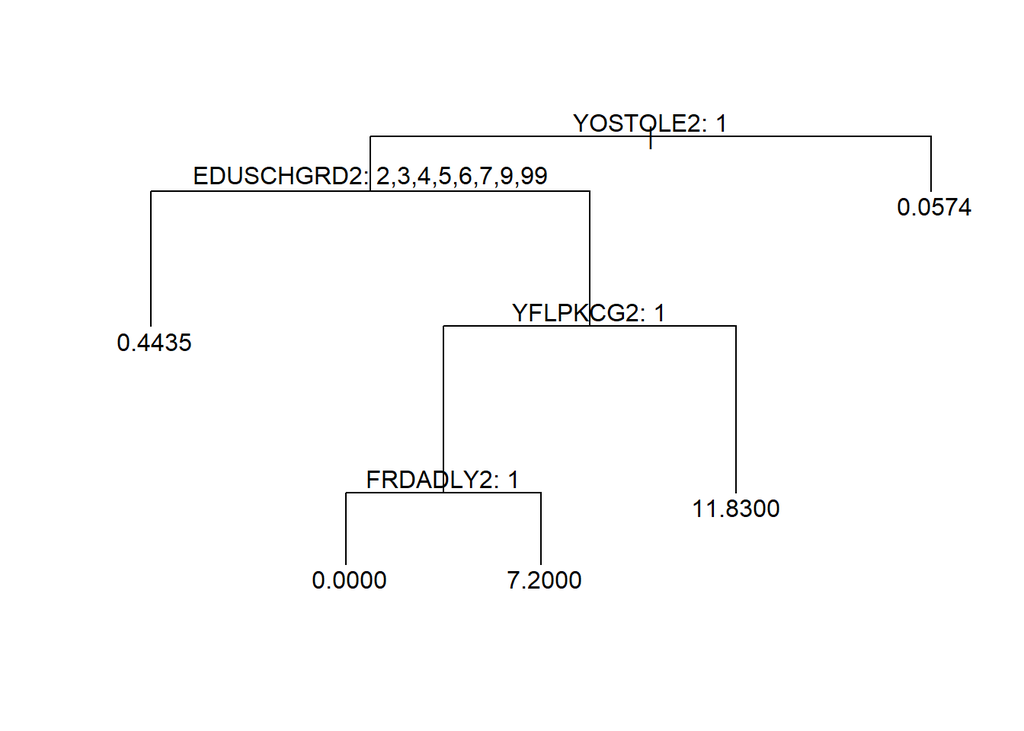

```r
plot(tree.cigarette)
text(tree.cigarette,pretty=0)
```

Attempts to prune tree were not successful, so we just stick with this complex, but manageable tree.

```r
# How does it perform?

# MSE if we just guess the mean value
 mean((cigarette.test$CIGARETTE-mean(cigarette.test$CIGARETTE))^2)
```

```
## [1] 0.2784835
```

```r
# model test MSE
pred <- predict(tree.cigarette,cigarette.test)
mean((pred-cigarette.test$CIGARETTE)^2)
```

```
## [1] 0.3529907
```

Our model performs worse than if we just guess the mean value… Can’t really saying anything about predictor importance.

### 3.3.2 Boosting

```r
set.seed(5322)

B <- c(100, 500, 1000)    # number of trees
d <- c(1,2)               # interaction depth
s <- c(0.1,0.01,0.001)    # shrinkage
test.MSE <- rep(0,3*2*3)  # validation scores
grid <- crossing(B,d,s,test.MSE)
for (i in 1:nrow(grid)) {
  # train model with corresponding B, d, and s
  boost.cigarette <- gbm(
    CIGARETTE ~ ., cigarette.train,
    distribution="gaussian",
    n.trees=grid[i,"B"],
    interaction.depth=grid[i,"d"],
    shrinkage=grid[i,"s"],
    verbose=FALSE
  )

  # measure validation score
  pred <- predict(boost.cigarette,cigarette.test, n.trees=grid[i,]$B)
  grid[i,"test.MSE"] <- mean((pred-cigarette.test$CIGARETTE)^2)
}
grid
```

```
## # A tibble: 18 × 4
##        B     d     s test.MSE
##    <dbl> <dbl> <dbl>    <dbl>
##  1   100     1 0.001    0.279
##  2   100     1 0.01     0.277
##  3   100     1 0.1      0.319
##  4   100     2 0.001    0.279
##  5   100     2 0.01     0.281
##  6   100     2 0.1      0.355
##  7   500     1 0.001    0.277
##  8   500     1 0.01     0.303
##  9   500     1 0.1      0.349
## 10   500     2 0.001    0.278
## 11   500     2 0.01     0.316
## 12   500     2 0.1      0.463
## 13  1000     1 0.001    0.277
## 14  1000     1 0.01     0.317
## 15  1000     1 0.1      0.357
## 16  1000     2 0.001    0.279
## 17  1000     2 0.01     0.344
## 18  1000     2 0.1      0.516
```

```r
set.seed(5322)

# use best parameter settings
boost.cigarette <- gbm(
  CIGARETTE ~ ., cigarette.train,
  distribution="gaussian",
  n.trees=100,
  interaction.depth=1,
  shrinkage=0.01,
  verbose=FALSE
)
```

```r
# How does it perform?

# base-line mse
base.mse <- mean((cigarette.test$CIGARETTE-mean(cigarette.test$CIGARETTE))^2)
base.mse
```

```
## [1] 0.2784835
```

```r
# model test MSE
pred <- predict(boost.cigarette,cigarette.test)
```

```
## Using 100 trees...
```

```r
model.mse <- mean((pred-cigarette.test$CIGARETTE)^2)
model.mse
```

```
## [1] 0.27669
```

```r
# reduction in MSE (can think of this as % of data explained)
1-model.mse/base.mse
```

```
## [1] 0.006440032
```

Model beats the null model (just barely), and so it makes sense to look at the relative influence:

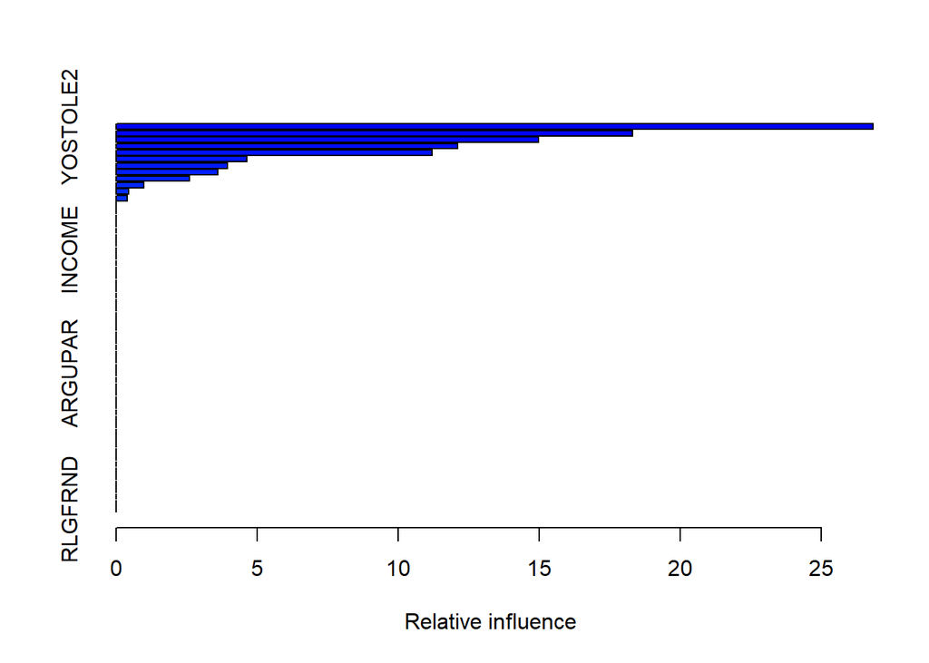

```
##                   var    rel.inf
## YOSTOLE2     YOSTOLE2 26.8356326
## YFLPKCG2     YFLPKCG2 18.3197837
## YOSELL2       YOSELL2 14.9688315
## EDUSCHLGO   EDUSCHLGO 12.0996552
## PRPKCIG2     PRPKCIG2 11.1987972
## YTHACT2       YTHACT2  4.6403407
## FRDADLY2     FRDADLY2  3.9432065
## PRMJMO         PRMJMO  3.5955530
## FRDPCIG2     FRDPCIG2  2.5972108
## FRDMEVR2     FRDMEVR2  0.9755064
## YOFIGHT2     YOFIGHT2  0.4383086
## FRDMJMON     FRDMJMON  0.3871737
## IRSEX           IRSEX  0.0000000
## NEWRACE2     NEWRACE2  0.0000000
## HEALTH2       HEALTH2  0.0000000
## EDUSCHGRD2 EDUSCHGRD2  0.0000000
## EDUSKPCOM   EDUSKPCOM  0.0000000
## IMOTHER       IMOTHER  0.0000000
## IFATHER       IFATHER  0.0000000
## INCOME         INCOME  0.0000000
## GOVTPROG     GOVTPROG  0.0000000
## POVERTY3     POVERTY3  0.0000000
## PDEN10         PDEN10  0.0000000
## COUTYP4       COUTYP4  0.0000000
## SCHFELT       SCHFELT  0.0000000
## TCHGJOB       TCHGJOB  0.0000000
## AVGGRADE     AVGGRADE  0.0000000
## STNDSCIG     STNDSCIG  0.0000000
## STNDSMJ       STNDSMJ  0.0000000
## STNDALC       STNDALC  0.0000000
## STNDDNK       STNDDNK  0.0000000
## PARCHKHW     PARCHKHW  0.0000000
## PARHLPHW     PARHLPHW  0.0000000
## PRCHORE2     PRCHORE2  0.0000000
## PRLMTTV2     PRLMTTV2  0.0000000
## PARLMTSN     PARLMTSN  0.0000000
## PRGDJOB2     PRGDJOB2  0.0000000
## PRPROUD2     PRPROUD2  0.0000000
## ARGUPAR       ARGUPAR  0.0000000
## YOGRPFT2     YOGRPFT2  0.0000000
## YOHGUN2       YOHGUN2  0.0000000
## YOATTAK2     YOATTAK2  0.0000000
## PRMJEVR2     PRMJEVR2  0.0000000
## PRALDLY2     PRALDLY2  0.0000000
## YFLTMRJ2     YFLTMRJ2  0.0000000
## YFLMJMO       YFLMJMO  0.0000000
## YFLADLY2     YFLADLY2  0.0000000
## TALKPROB     TALKPROB  0.0000000
## PRTALK3       PRTALK3  0.0000000
## PRBSOLV2     PRBSOLV2  0.0000000
## PREVIOL2     PREVIOL2  0.0000000
## PRVDRGO2     PRVDRGO2  0.0000000
## GRPCNSL2     GRPCNSL2  0.0000000
## PREGPGM2     PREGPGM2  0.0000000
## DRPRVME3     DRPRVME3  0.0000000
## ANYEDUC3     ANYEDUC3  0.0000000
## RLGATTD       RLGATTD  0.0000000
## RLGIMPT       RLGIMPT  0.0000000
## RLGDCSN       RLGDCSN  0.0000000
## RLGFRND       RLGFRND  0.0000000
```

```r
# variable relative influence
summary(boost.cigarette)
```

Sharing some overlap with the decision tree, the the following predictors seem to be the most important: in order,

- `YOSTOLE2`: Youth stole or tried to steal and item more expensive than $50
- `YFLPKCG2`: How youth feels about peers smoking
- `YOSELL2`: Has youth sold illegal drugs
- `EDUSCHLGO`: Is the youth going to school
- `PRPKCIG2`: How youth thinks their parents feel about them smoking 1+ pack a day